# 🎉 Welcome to the Ultimate Jupyter Notebook Tutorial! 🎉

In this notebook, we'll explore all the cool things you can do with Jupyter Notebooks! From text formatting to visualizations, and even interactive widgets, you'll learn it all here. Let's get started!

## 🔤 Headings: Organize Like a Pro

Headings are a great way to structure your notebook. Just use `#` for different heading levels.

Here's how they look:

# Heading 1 (Biggest!)

## Heading 2

### Heading 3

#### Heading 4

*Try writing your own heading below!*

# Insert heading here :)

## ✨ Text Formatting: Make It Pop!

Want to make something bold? **Use double asterisks!** Want italics? *Single asterisks do the trick!* Need both? **Go wild with triple asterisks!**

*Pro tip: Use formatting to highlight important notes in your analysis.*

# Give it a try here :)

## 🔢 Lists: Keep It Neat

### Bullet Points:

- Point 1
- Point 2
  - Sub-point 2.1
  - Sub-point 2.2

### Numbered Lists:

1. First
2. Second
3. Third

*Lists are perfect for step-by-step instructions or summarizing findings.*

# Make a list below of why you are an awesome person.

eg

Tara is awesome because:

- She drinks the most tea in the NanoDTC
- She makes a mean Lentil Dahl

## 🔗 Links and Images: Spice Things Up

Want to link to something cool? Use this format:

[Click me to visit Google!](https://www.google.com)

*Try adding a link or an image that inspires you!*

# Insert your link here :)

## 🧮 Math Mode: For All You Math Geeks

Jupyter Notebooks support LaTeX for writing equations. Just wrap your equations in `$` for inline math or `$$` for block math. - Inline: $E = mc^2$ - Block: $$\int_{-\infty}^{\infty} e^{-x^2} dx = \sqrt{\pi}$$

*Math never looked so good!*

# What's your favourite formula?

## 🧱 Code Blocks: Show Your Magic

You can add code directly in Markdown for examples: `print("Hello World")`

Or wrap it in triple backticks for a block:

```
def greet():
    print("Hello, Jupyter!")
greet()
```

*Time to show off your coding chops!*

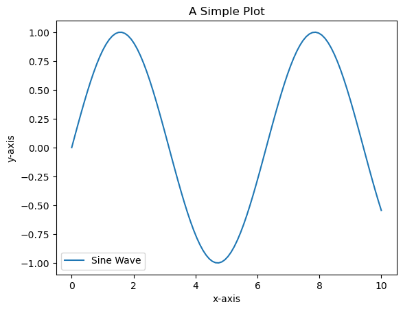

```python
# 🚀 Python Code Cell: This is how you write Python code in a notebook


import numpy as np
import matplotlib.pyplot as plt

# Generate some data
x = np.linspace(0, 10, 100)
y = np.sin(x)

# Plot it
plt.plot(x, y, label='Sine Wave')
plt.title('A Simple Plot')
plt.xlabel('x-axis')
plt.ylabel('y-axis')
plt.legend()
plt.show()
```

## 📊 Tables: Keep It Tabular

| Name | Age | Role |
| --- | --- | --- |
| Alice | 25 | Scientist |
| Bob | 30 | Engineer |
| Charlie | 22 | Designer |

*Tables are great for organizing data summaries.*

# Make a table of all the people in the room with you below.

## 🎛 Interactive Widgets: Make It Fun

Widgets let you add interactivity to your notebooks! Try running the cell below to see an interactive slider in action:

```python
from ipywidgets import interact

def square(x):
    return x ** 2

interact(square, x=(0, 10));
```

```
interactive(children=(IntSlider(value=5, description='x', max=10), Output()), _dom_classes=('widget-interact',…
```

## 📚 More Resources for the Basics :)

Want to learn more about Jupyter Notebooks or Markdown? Check out these resources:

- [Jupyter Notebook Documentation](https://jupyter-notebook.readthedocs.io/en/stable/)
- [Markdown Guide](https://www.markdownguide.org/)

# Level up time! Advanced Notebook functionalities

## 🪄 Magic Commands: Boost Productivity

Jupyter comes with special commands called *magic commands*. These can help you run shell commands, time your code, or even change the behavior of your notebook.

```python
# %%time: Time the execution of a cell
import time
start_time = time.time()
time.sleep(2)  # Simulate a 2-second task
print("Finished!")
print("Execution Time:", time.time() - start_time)
```

```
Finished!
Execution Time: 2.0037569999694824
```

```python
# !: Run shell commands directly in the notebook
!ls  # Lists files in your directory
```

```
000_markdown.ipynb           005_advanced_functions.ipynb
001_syntacs.ipynb            006_oop.ipynb
002_inputs_and_outputs.ipynb 007_exception_handling.ipynb
003_datatypes.ipynb          008_filehandling.ipynb
004_functions.ipynb
```

## 🎛 Dynamic Widgets: Control Parameters Easily

You can use sliders, dropdowns, and more to interactively adjust parameters in your analysis.

```python
import ipywidgets as widgets
from IPython.display import display

# Create sliders
slider = widgets.IntSlider(value=5, min=0, max=10, step=1, description="Slider:")
text_box = widgets.Text(value="Type here", description="Text Box:")

# Display widgets
display(slider, text_box)

# Use widget values dynamically
def update_slider(change):
    print(f"Slider value: {change['new']}")

slider.observe(update_slider, names='value')
```

```
IntSlider(value=5, description='Slider:', max=10)
```

```
Text(value='Type here', description='Text Box:')
```

```
Slider value: 6
Slider value: 7
Slider value: 8
Slider value: 7
Slider value: 6
Slider value: 5
Slider value: 4
Slider value: 5
Slider value: 6
Slider value: 5
Slider value: 4
Slider value: 3
Slider value: 2
Slider value: 0
Slider value: 1
Slider value: 2
Slider value: 4
Slider value: 5
Slider value: 7
Slider value: 8
Slider value: 9
Slider value: 10
```

## 📤 Export Your Notebook

Did you know you can export this notebook to other formats like PDF or HTML? Use the command below in the terminal or Jupyter interface.

```python
!jupyter nbconvert --to html 000_markdown.ipynb
```

```
[NbConvertApp] Converting notebook 000_markdown.ipynb to html
[NbConvertApp] WARNING | Alternative text is missing on 1 image(s).
[NbConvertApp] Writing 507130 bytes to 000_markdown.html
```

## 🧮 Advanced Math in LaTeX

Add detailed equations to explain complex concepts. Here's an example:

$$\text{Fourier Transform:}\ \hat{f}(\xi) = \int_{-\infty}^{\infty} f(x) e^{-2\pi i x \xi} dx$$

$$\text{Partial Differential Equation:}\ \frac{\partial u}{\partial t} = c^2 \nabla^2 u$$

## 📊 DataFrame Styling: Make Tables Look Better

Pandas lets you style your DataFrames for clear and beautiful displays.

```python
import pandas as pd

# Example DataFrame
df = pd.DataFrame({
    "Experiment": ["A", "B", "C"],
    "Result": [0.85, 0.92, 0.88]
})

# Style DataFrame
df.style.background_gradient(cmap="coolwarm").set_caption("Styled DataFrame")
```

Styled DataFrame

|  | Experiment | Result |
| --- | --- | --- |
| 0 | A | 0.850000 |
| 1 | B | 0.920000 |
| 2 | C | 0.880000 |

## 📽 Embedding Multimedia

You can embed videos, audio files, or even GIFs directly into your notebook.

### Embed a YouTube Video

[Click here for a video](https://www.youtube.com/watch?v=dQw4w9WgXcQ)

## ✅ To-Do List for Data Analysis

- Load the data
- Clean the data
- Perform analysis
- Create visualizations
- Write the report

## 🔧 Running Shell Commands

Run shell commands directly in the notebook for file handling or setup tasks.

```python
!mkdir data
!echo "Hello, Jupyter!" > data/hello.txt
!cat data/hello.txt
```

[output not shown]

## 🗂 Widgets for File Uploads

Let users upload files directly into the notebook.

```python
uploader = widgets.FileUpload()
display(uploader)

# Access the uploaded file
def on_upload_change(change):
    for filename, content in uploader.value.items():
        print(f"Uploaded file: {filename}")

uploader.observe(on_upload_change, names='value')
```

```
FileUpload(value=(), description='Upload')
```

## 🗺 Interactive Maps

Use `folium` for interactive map visualizations.

```python
import folium

# Create a map
m = folium.Map(location=[51.9522, 7.8497], zoom_start=13)

# Add a marker
folium.Marker([51.9522, 7.8497], popup="Somewhere in the middle of nowhere..").add_to(m)

m
```

Make this Notebook Trusted to load map: File -> Trust Notebook

[interactive chart not shown]